# Week 6 Activity: STFT and Spectral Features

Complete this activity as part of your participation grade. Pending length of the lecture, you will have time in class to work. Everything you need to complete this activity can be found in this week's (or a previous week's) lecture code.

```python
import numpy as np
import matplotlib.pyplot as plt
from scipy import signal
from scipy.signal import stft
from scipy.fftpack import fftshift
from IPython.display import Image, Audio, Math
import matplotlib.pyplot as plt
import matplotlib.colors as colors
from scipy.signal import stft
from scipy.io.wavfile import read
```

```python
def cSine(k, N):
    """
    Inputs:
        k (integer) = frequency index of the complex sinusoid of the DFT
        N (integer) = length of complex sinusoid in samples
    Output:
        The function should return a numpy array
        cSine (numpy array) = The generated complex sinusoid (length N)
    """
    n = np.arange(0, N) #numpy array whose length is the samples over time
    out = np.cos(2*np.pi * k * n/N) - 1j*(np.sin(2*np.pi * k * n/N))

    return out

def myDFT2(x, plot=False):
    import matplotlib.pyplot as plt
    """
    Input:
    x (numpy array) = input sequence of length N
    Output:
    The function should return a numpy array of length N
    X (numpy array) = The N point DFT of the input sequence x
    """
    ## Your code here
    N = len(x)

    X = np.array([]) #initialize numpy array
    for k in range(N):
        X = np.append(X, np.sum(x * cSine(k, N)))

    if plot:

        kv=np.arange(-N/2, N/2)
        Xmodded = np.array([])
        for k in kv:
            Xmodded = np.append(Xmodded, sum(x * cSine(k, N)))

        plt.plot(kv, abs(Xmodded))
        plt.title('mag. spectrum of real-valued signal')
        plt.xlabel('frequency')
        plt.ylabel('amplitude')
        plt.xlim(0,10)

        plt.tight_layout()
        plt.show()

    return
```

## Windowing and STFT

Compute the DFT of an "on bin" (integer bin) sinusoid and plot.

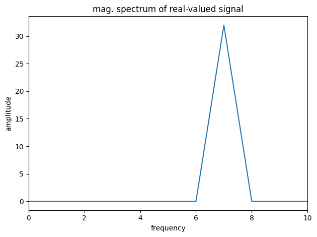

```
None
```

```python
N = 64

n = np.arange(0, N)
onbin = np.sin(2 * np.pi * 7 * n/N)

print(myDFT2((np.array(onbin)), plot=True))
```

Compute the DFT of an off bin sinusoid and plot.

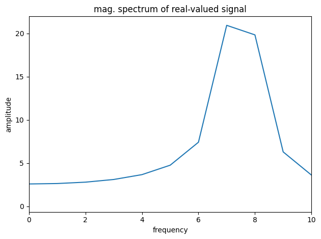

```
None
```

```python
offbin = np.sin(2 * np.pi * 7.5 * n/N)

print(myDFT2((np.array(offbin)), plot=True))
```

Apply a hanning window to both sinusoids and recompute the DFT and plot.

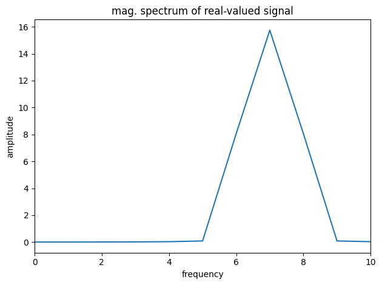

```
None
```

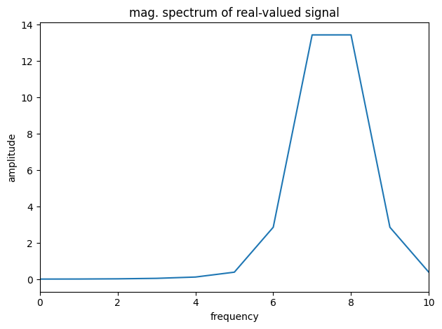

```
None
```

```python
window = np.hanning(N)

onbin_win = onbin * window

print(myDFT2((np.array(onbin_win)), plot=True))

offbin_win = offbin * window

print(myDFT2((np.array(offbin_win)), plot=True))
```

Apply a blackman harris window to both sinusoids and recompute the DFT and plot.

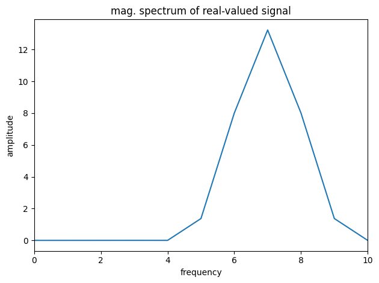

```
None
```

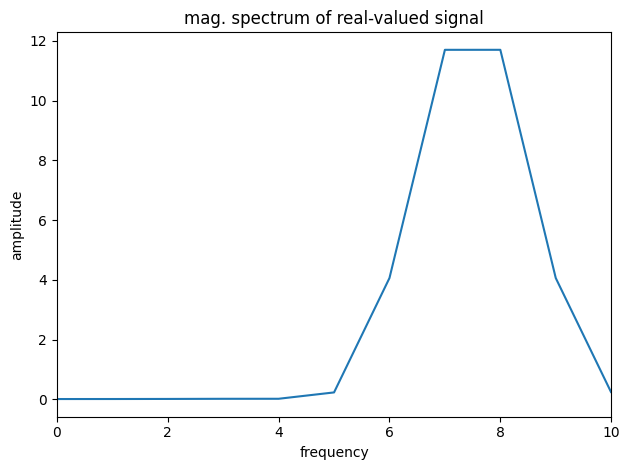

```
None
```

```python
window2 = np.blackman(N)

onbin_win2 = onbin * window2

print(myDFT2((np.array(onbin_win2)), plot=True))

offbin_win2 = offbin * window2

print(myDFT2((np.array(offbin_win2)), plot=True))
```

Describe what happened in all of the above cases. What happened to the frequency resolution, was their leakage, what do the side/main lobes look like?

In the case of the offbin sunusoid, there was spectral leakage before the windows were applied. When the windows were applied, the frequency resolution was decreased. The lobes are spread out in these cases.

## Applying the STFT

Apply the STFT (use scipy.stft) to one of the files listed below, then graph the spectrogram.

- 'BobMarley_track1.wav'
- 'MilesDavis_track2.wav'
- 'Radiohead_track3.wav'
- 'TheBlackKeys_track4.wav'

See what happens when you change:

- the frame size (nperseg)
- the window type
- the amount of overlap
- the amount of padding (nfft)

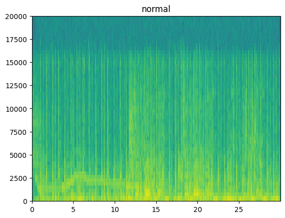

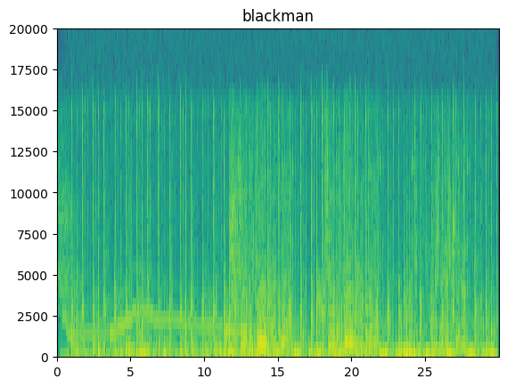

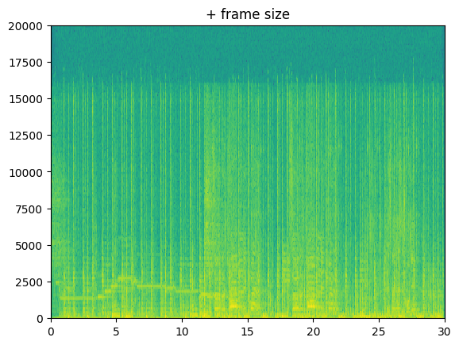

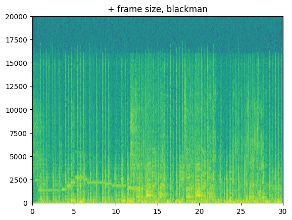

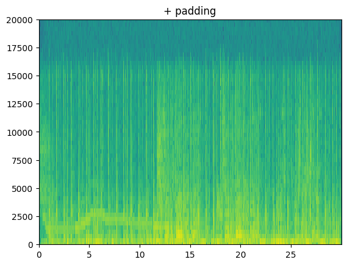

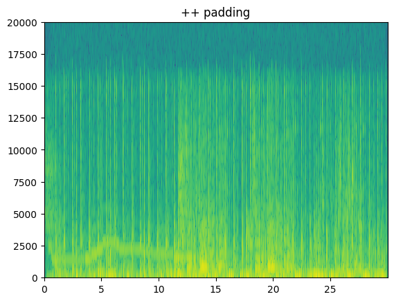

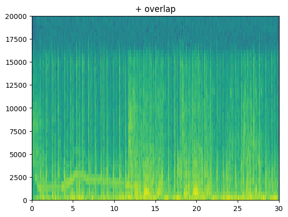

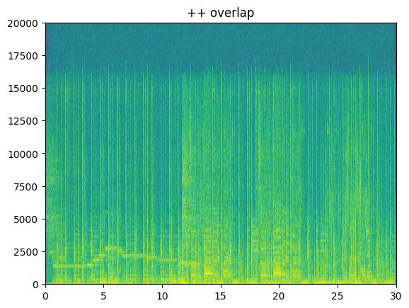

```python
(fs, x) = read("../audio/BobMarley_track1.wav")

f1,t1,Z1 = stft(x, fs=fs)
f2,t2,Z2 = stft(x, fs=fs, window='blackman')
f3,t3,Z3 = stft(x, fs=fs, nperseg=1028)
f4,t4,Z4 = stft(x, fs=fs, nperseg=1028, window='blackman')
f5,t5,Z5 = stft(x, fs=fs, nfft=256)
f6,t6,Z6 = stft(x, fs=fs, nfft=1028)
f7,t7,Z7 = stft(x, fs=fs, noverlap=64)
f8,t8,Z8 = stft(x, fs=fs, nperseg=1024, noverlap=512)

plt.pcolormesh(t1,f1,20*np.log10(np.abs(Z1)))
plt.ylim(0,20000)
plt.title('normal')
plt.show()
plt.pcolormesh(t2,f2,20*np.log10(np.abs(Z2)))
plt.ylim(0,20000)
plt.title('blackman')
plt.show()
plt.pcolormesh(t3,f3,20*np.log10(np.abs(Z3)))
plt.ylim(0,20000)
plt.title('+ frame size')
plt.show()
plt.pcolormesh(t4,f4,20*np.log10(np.abs(Z4)))
plt.ylim(0,20000)
plt.title('+ frame size, blackman')
plt.show()
plt.pcolormesh(t5,f5,20*np.log10(np.abs(Z5)))
plt.ylim(0,20000)
plt.title('+ padding')
plt.show()
plt.pcolormesh(t6,f6,20*np.log10(np.abs(Z6)))
plt.ylim(0,20000)
plt.title('++ padding')
plt.show()
plt.pcolormesh(t7,f7,20*np.log10(np.abs(Z7)))
plt.ylim(0,20000)
plt.title('+ overlap')
plt.show()
plt.pcolormesh(t8,f8,20*np.log10(np.abs(Z8)))
plt.ylim(0,20000)
plt.title('++ overlap')
plt.show()
```

## STFT Pseudo Code

For HW3, you will write your own STFT function. To get you started on that process, write out the pseudocode for the STFT. You should expect similar inputs to the scipy.stft function.

```python
# See what happens when you change:
# - the frame size (nperseg)
# - the window type
# - the amount of overlap
# - the amount of padding (nfft)

#def stft(x, framesize, wtype, overlap, padding)

    #window = wtype
    #add padding to signal if necessary

    #divide x up by the frame size
    #for frame in x
        #multiply by window

    #add windows together with overlap
```

## Spectral Features

Using the `librosa.feature` functions, calculate the various features below as described.

**Choose two of the four tracks below** and use the same pair of tracks for each feature extraction activity.

- 'BobMarley_track1.wav'
- 'MilesDavis_track2.wav'
- 'Radiohead_track3.wav'
- 'TheBlackKeys_track4.wav'

```python
from librosa import frames_to_time, stft, amplitude_to_db, display
from librosa.feature import mfcc, spectral_bandwidth, spectral_centroid
```

### Bandwidth

Look up the function documentation [here](https://librosa.org/doc/0.8.0/generated/librosa.feature.spectral_bandwidth.html).

For Track (a) and Track (b), calculate the bandwidth using the `spectral_bandwidth` function. Compare the change in output for both (a) and (b) using two different FFT sizes in your STFT: one relatively small, and the other relatively large.

Plot your results for each by plotting the normalized audio and normalized feature on top of each other. (You may do this using the `frames_to_time` function if you wish.) Your graph output should be a 4x4 grid (2 songs, 2 different FFT sizes).

```python
(fs, a) = read('../audio/MilesDavis_track2.wav')
(fs2, b) = read('../audio/Radiohead_track3.wav')
#print(fs, fs2)


a = a.astype(float)
b = b.astype(float)

miles_time = np.arange(0,a.size)/fs
rh_time = np.arange(0,b.size)/fs

miles_data = a/np.max(abs(a))
rh_data = b/np.max(abs(b))

frame_length1 = 2048
hop_length1 = 1024
frame_length2 = 256
hop_length2 = 128

ban_miles1 = spectral_bandwidth(y=miles_data, sr=fs, n_fft=frame_length1, hop_length=hop_length1)[0]
ban_miles2 = spectral_bandwidth(y=miles_data, sr=fs, n_fft=frame_length2, hop_length=hop_length2)[0]

ban_rh1 = spectral_bandwidth(y=rh_data, sr=fs, n_fft=frame_length1, hop_length=hop_length1)[0]
ban_rh2 = spectral_bandwidth(y=rh_data, sr=fs, n_fft=frame_length2, hop_length=hop_length2)[0]
```

Always check the sampling rates - you want to make sure that you are using the same sampling rate when making comparisons. If they are not the same, you will need to downsample the ones that are too high (or, alternatively, downsample all of them so that they are 22.05kHz). One way is to use `librosa` to read in the files - it has an argument for you to specify the sample rate you want:

```python
# the 'load' package from librosa was already installed
# note that librosa saves the sample rate and data in the opposite order
(data, fs) = load('../uploaded_files/BobMarley_track1.wav', sr=44100)#note that 22050 is the default for the "load" function
print(fs, data.shape)
```

[output not shown]

The other way is via the `signal.resample` function from `scipy`. Be careful if you choose to do it this way since the sample rate you saved when loading is no longer the correct sample rate. When the sample rate is 96kHz, it's a bit tricky this way:

```python
#First, read in as usual:
(fs, a) = read('../uploaded_files/BobMarley_track1.wav')
#Then, downsample:
#size of original in s:
t = a.size/fs
#length of samples you would have with 44.1kHz (desired) sample rate:
newl = int(np.ceil(t*44100)) #must be integer number of samples
ads = signal.resample(a, newl).astype(float) #signal to resample, total samples in new output
print(ads.shape)
```

[output not shown]

```python
sb_a1 = feature.spectral_bandwidth(y=ads, sr=fs, n_fft=4096, hop_length=2048)[0]
sb_a2 = feature.spectral_bandwidth(y=ads, sr=fs, n_fft=512, hop_length=256)[0]

sb_b1 = feature.spectral_bandwidth(y=b, sr=fs, n_fft=4096, hop_length=2048)[0]
sb_b2 = feature.spectral_bandwidth(y=b, sr=fs, n_fft=512, hop_length=256)[0]

print(sb_a1.shape, sb_a2.shape, sb_b1.shape, sb_b2.shape) #check to ensure similar num of windows
```

[output not shown]

```python
def normalize(x):
    n = x/abs(x.max())
    return(n)
```

```python
frames1 = range(len(sb_a1))
t1 = frames_to_time(frames1, sr=44100, hop_length=2048, n_fft=4096)
n_sba1 = normalize(sb_a1) #normalize sb values
time = np.arange(0, ads.size/44100, 1/44100)
n_a = normalize(ads) #normalize audio
plt.plot(time, n_a, 'b', t1, n_sba1, 'r');
#plt.plot(t1,n_sba1)
```

[output not shown]

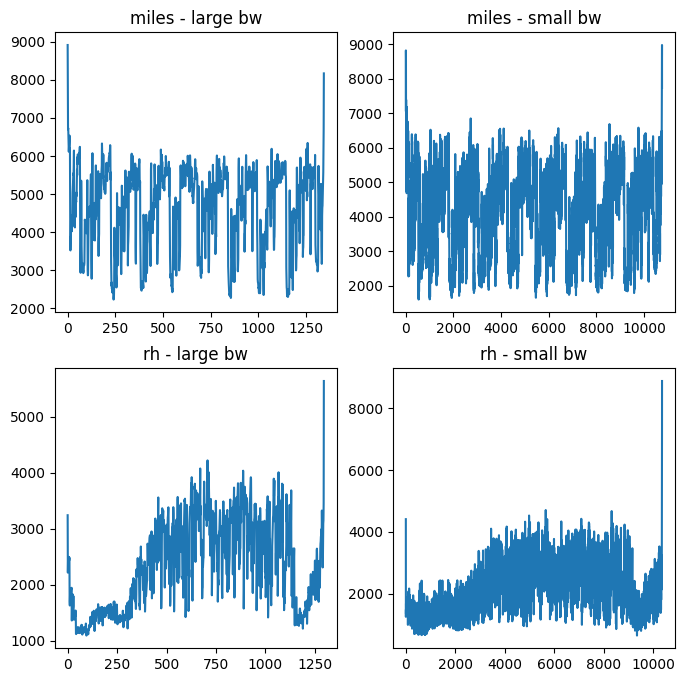

```python
(fig, ax) = plt.subplots(2,2,figsize=(8,8))
ax[0,0].plot(ban_miles1)
ax[0,0].set_title('miles - large bw')
ax[0,1].plot(ban_miles2)
ax[0,1].set_title('miles - small bw')

ax[1,0].plot(ban_rh1)
ax[1,0].set_title('rh - large bw')
ax[1,1].plot(ban_rh2)
ax[1,1].set_title('rh - small bw')
```

For discussion: Listen to each track. What timbral features of the track are obviously different? What, if anything, might affect the decision to use a short or long FFT size? Keep in mind you would have to use the same FFT size for all tracks you want to compare (otherwise you are comparing apples and oranges!)

```python
Audio(miles_data, rate=fs)
#Audio(rh_data, rate=fs)
```

[interactive chart not shown]

for one, the instrumentation of the two tracks is entirely different. the miles track has cymbals and horns, and seems to be generally quieter. the radiohead track seems a bit louder and has enery in the range of the human voice and alot of low-mid frequencies that are present throughout. the fft size is dependent on whether or not you want to prioritize frequency or time resolution.

### Spectral Centroid

Look up the function documentation [here](https://librosa.org/doc/0.8.0/generated/librosa.feature.spectral_centroid.html).

For Track (a) and Track (b), calculate the bandwidth using the `spectral_centroid` function. Compare the change in output for both (a) and (b) using a fixed FFT size of your choice but two different FFT overlaps: one with no overlap, and the other with 50% overlap.

Plot your results for each by plotting the normalized audio and normalized feature on top of each other. (You may do this using the `frames_to_time` function if you wish.) Your graph output should be a 4x4 grid (2 songs, 2 different hop sizes).

```python
miles_norm = normalize(miles_data)

miles_cen1 = spectral_centroid(y=miles_data.astype(float), sr=fs, hop_length=1024)
miles_cen2 = spectral_centroid(y=miles_data.astype(float), sr=fs, hop_length=2048)

miles_cen1 = normalize(miles_cen1)
miles_cen2 = normalize(miles_cen2)

rh_norm = normalize(rh_data)

rh_cen1 = spectral_centroid(y=rh_data.astype(float), sr=fs, hop_length=1024)
rh_cen2 = spectral_centroid(y=rh_data.astype(float), sr=fs, hop_length=2048)

rh_cen1 = normalize(rh_cen1)
rh_cen2 = normalize(rh_cen2)

(fig, ax) = plt.subplots(2,2,figsize=(8,8))
ax[0,0].plot(miles_norm)
ax[0,0].plot(miles_cen1)
ax[0,0].set_title('miles - 50% overlap')
ax[0,1].plot(miles_norm)
ax[0,1].plot(miles_cen2)
ax[0,1].set_title('miles - no overlap')

ax[1,0].plot(rh_norm)
ax[1,0].plot(rh_cen1)
ax[1,0].set_title('rh - 50% overlap')
ax[1,1].plot(rh_norm)
ax[1,1].plot(rh_cen2)
ax[1,1].set_title('rh - no overlap')
```

[output not shown]

For discussion: What, if anything, changes as a result of changing the hop size? Is it predictable?

### Mel Frequency Cepstrum Coefficients (MFCCS)

Look up the function documentation [here](https://librosa.github.io/librosa/generated/librosa.feature.mfcc.html).

Calculate the MFCCs for Track (a) and Track (b). Make two plots of the output: (1) set the n_mfcc parameter to 12, and (2) to 20. Again you should have a total of 4 plots.

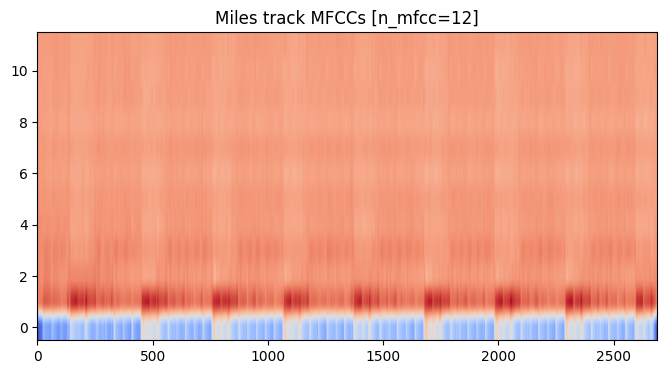

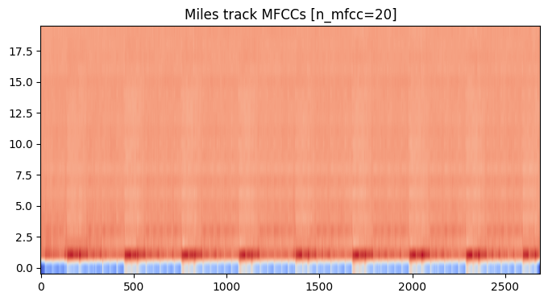

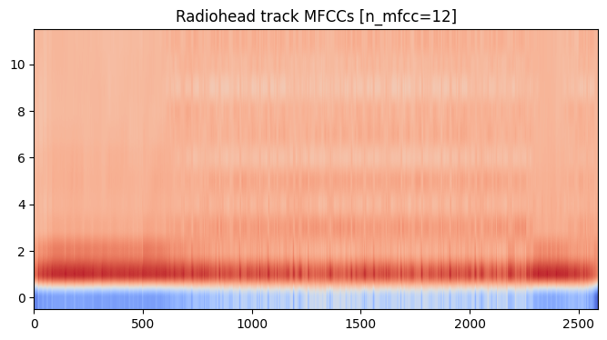

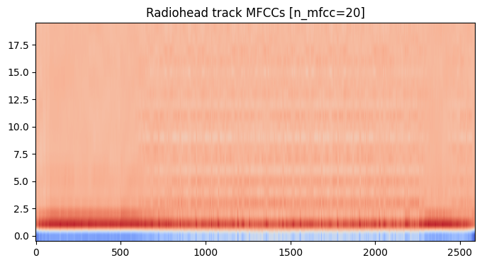

```python
m_mfcc1 = mfcc(y=miles_data, sr=fs, n_mfcc=12)
m_mfcc2 = mfcc(y=miles_data, sr=fs, n_mfcc=20)

r_mfcc1 = mfcc(y=rh_data, sr=fs, n_mfcc=12)
r_mfcc2 = mfcc(y=rh_data, sr=fs, n_mfcc=20)

plt.figure(figsize=(8,4))
plt.imshow(m_mfcc1, aspect='auto', origin='lower', cmap='coolwarm')
plt.title('Miles track MFCCs [n_mfcc=12]')
plt.show()
plt.figure(figsize=(8,4))
plt.imshow(m_mfcc2, aspect='auto', origin='lower', cmap='coolwarm')
plt.title('Miles track MFCCs [n_mfcc=20]')
plt.show()
plt.figure(figsize=(8,4))
plt.imshow(r_mfcc1, aspect='auto', origin='lower', cmap='coolwarm')
plt.title('Radiohead track MFCCs [n_mfcc=12]')
plt.show()
plt.figure(figsize=(8,4))
plt.imshow(r_mfcc2, aspect='auto', origin='lower', cmap='coolwarm')
plt.title('Radiohead track MFCCs [n_mfcc=20]')
plt.show()
```